# BANA 4080: Introduction to Data Mining with Python

Week 10: From Numbers to Categories

## Welcome to Week 10

- Quick overview of today’s plan:
  - From predicting numbers to predicting categories
  - Logistic regression and the S-shaped curve
  - Interpreting coefficients and probabilities
  - Why 97% accuracy can be terrible
  - Choosing the threshold and metric that fit the business

## 📓 Follow Along in the Notebook

**Week 10 Lecture Notebook**

Open the companion notebook in Colab now and follow along as we work through today’s examples on logistic regression and classification evaluation.

[figure not shown]

Open In Colab

# Week 9 Recap

## Last Week in 60 Seconds

📈 Linear regression

Fit a line $y = \beta_0 + \beta_1 x$ to predict a **number**

*Ad spend → weekly sales*

📏 RMSE & R²

**RMSE:** how far off, typically (in $)

**R²:** how much better than guessing the average

🔒 Train/test split

Score the model on data it **never saw** while learning

🧠 The memorizer

A perfect training score can hide a model that learned nothing useful

**Tip**

Today the **target is a category**, but the workflow (split → fit → predict → evaluate against a baseline) stays the same.

# Predicting Numbers Categories

## Not Every Business Question is About Numbers

**Week 9:** We predicted continuous values…

- *How much revenue will we generate?*
- *What price should we set for this product?*
- *What will our customer lifetime value be?*

**Today:** Many critical decisions involve categories…

- *Will this customer default on their loan?* (Yes/No)
- *Is this email spam?* (Spam/Not Spam)
- *Should we approve this application?* (Approve/Deny)
- *Will this marketing campaign succeed?* (Success/Failure)

## Flip It: Regression → Classification

Each question below predicts a **number**. With your neighbor, rewrite it so the model predicts a **category** instead.

1. 🛒 *How much will this customer spend next month?*
2. 🏠 *What price will this house sell for?*
3. 📦 *How many days late will this shipment arrive?*

**One possible flip for each:**

1. *Will this customer spend more than $100?* (Yes/No)
2. *Will this house sell above asking price?* (Yes/No)
3. *Will this shipment arrive late?* (On time/Late)

**Tip**

Same business, same data. **The target decides** whether it’s regression or classification.

## Draw the Line

Each dot is a customer: their **credit card balance** and whether they **defaulted** (1) or not (0).

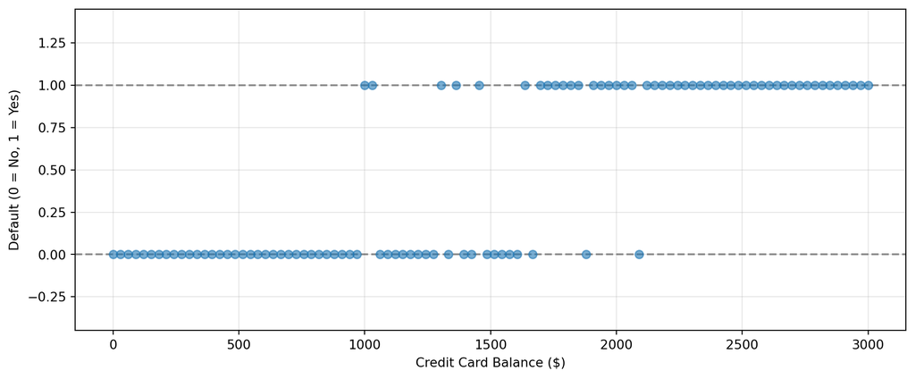

**Using what you learned last week:** how would you draw a line to model this relationship?

## Here’s What Linear Regression Draws

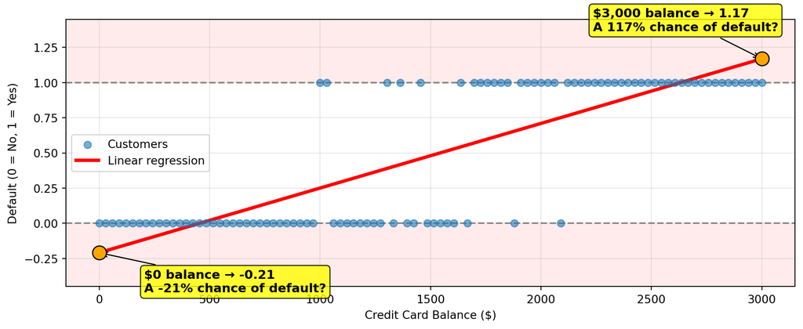

- **Impossible predictions**: the line runs below 0 and above 1 (the shaded zones), so it can’t be a probability
- **Wrong shape**: risk stays near 0 at low balances, climbs fast in the middle, then levels off near 1. A straight line can’t bend to follow that

## What Shape Would You Draw Instead?

If you could draw **any** shape through those points, one that stays between 0 and 1 and bends where risk changes fastest, what would it look like?

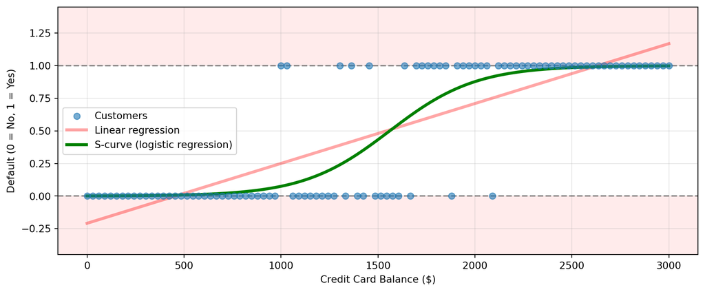

An **S-curve**: flat near 0, a steep climb in the middle, then flat near 1. Every point on it is a valid probability. Building that curve is exactly what **logistic regression** does.

# Logistic Regression: The S-Shaped Solution

## The Logistic Function

**Key Innovation:** Transform linear predictions into probabilities using the logistic function:

$$p = \frac{1}{1 + e^{-z}}$$

where $z = \beta_0 + \beta_1 x_1 + \beta_2 x_2 + ...$

**Tip**

Does $z$ look familiar? 🤔

*This equation takes any number (our risk score $z$) and squeezes it between 0 and 1 to create a valid probability.*

## Creates Valid Probabilities

**Magic Properties:**

- **Always between 0 and 1** - perfect for probabilities!
- **S-shaped curve** - captures realistic business relationships
- **Smooth transitions** - gradual probability changes, not jumps
- **50% at center** - when z = 0, probability = exactly 50%

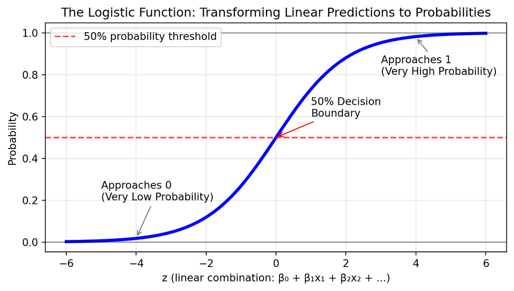

## Using the S-Curve for Business Decisions

The S-shaped curve gives us **two powerful tools** for business decision-making:

**1. Probability Estimates:** Get the exact chance an event will happen (0-100%)

**2. Binary Classifications:** Make yes/no decisions using a threshold (50% by default)

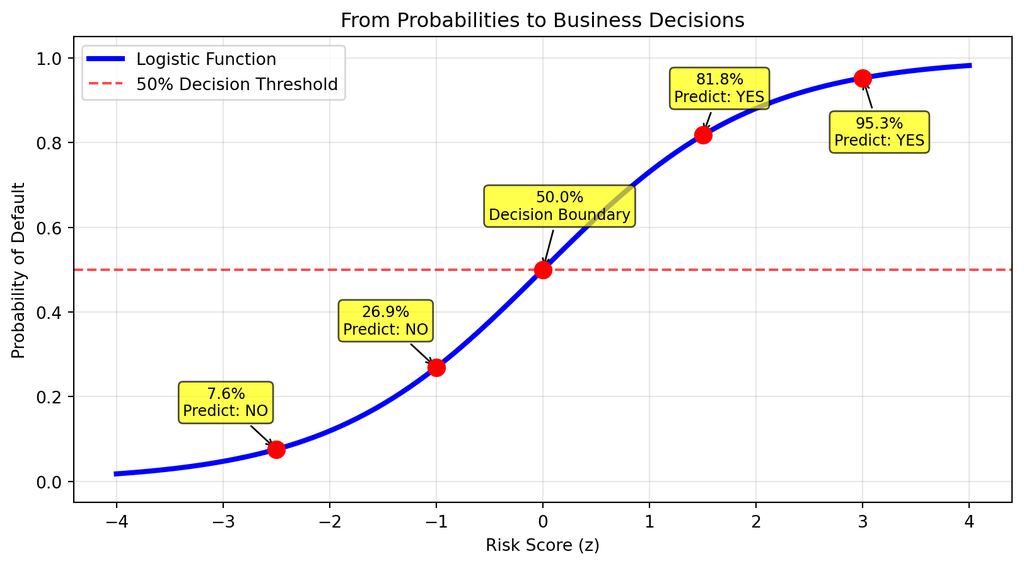

**Key Insight:** Every prediction gives you a probability between 0-100%. A **threshold** (50% unless we choose otherwise) turns it into a yes/no decision. Hold onto that “unless we choose otherwise”…

## Probability or Decision?

🎲 Probability estimate

*“This customer has a 12% chance of defaulting”*

✅ Classification

*“Approve this application”*

**With your neighbor, identify:**

1. **2 business scenarios** where you’d want the **probability**
2. **2 business scenarios** where you’d want just the **yes/no decision**

**Then discuss:** What makes the probability more useful in some situations?

# Let’s Build Our First Logistic Regression Model

## Meet the Default Data

**Step 1:** Load the ISLP `Default` data: 10,000 credit card customers

```python
from ISLP import load_data

# Load the Default dataset
Default = load_data('Default')
Default[['default', 'balance', 'income']].head()
```

|  | default | balance | income |
| --- | --- | --- | --- |
| 0 | No | 729.526495 | 44361.625074 |
| 1 | No | 817.180407 | 12106.134700 |
| 2 | No | 1073.549164 | 31767.138947 |
| 3 | No | 529.250605 | 35704.493935 |
| 4 | No | 785.655883 | 38463.495879 |

```python
# What share of customers actually defaulted?
Default['default'].value_counts(normalize=True)
```

```
default
No     0.9667
Yes    0.0333
Name: proportion, dtype: float64
```

**Only about 3% of customers default.** Remember this number. 👀

## Split, Then Fit

**Step 2:** Split the data the same way as last week, then fit on the training set only

```python
from sklearn.model_selection import train_test_split
from sklearn.linear_model import LogisticRegression

# Features and a 0/1 target (1 = defaulted)
X = Default[['balance', 'income']]
y = (Default['default'] == 'Yes').astype(int)

X_train, X_test, y_train, y_test = train_test_split(
    X, y, test_size=0.3, random_state=42, stratify=y
)

# Fit logistic regression on the training data
model = LogisticRegression()
model.fit(X_train, y_train)

print(f"Intercept:           {model.intercept_[0]:.4f}")
print(f"Balance coefficient: {model.coef_[0][0]:.6f}")
print(f"Income coefficient:  {model.coef_[0][1]:.6f}")
```

```
Intercept:           -11.5977
Balance coefficient: 0.005751
Income coefficient:  0.000019
```

`stratify=y` keeps the ~3% default rate the same in both the training and test sets.

**So, what do these coefficients mean?** 🤔

## Probability, Odds, and Log-Odds

To interpret logistic regression coefficients, we need three related concepts:

- **Probability:** The familiar 0-100% chance something happens
- **Odds:** Ratio of probability it happens vs. doesn’t happen (probability / (1 - probability))
- **Log-Odds:** Natural logarithm of the odds

| **Probability** | **Odds** | **Log-Odds** | **Business Interpretation** |
| --- | --- | --- | --- |
| 10% | 0.11 | -2.20 | Very unlikely event |
| 25% | 0.33 | -1.10 | Unlikely event |
| 50% | 1.00 | 0.00 | Neutral (decision boundary) |
| 75% | 3.00 | 1.10 | Likely event |
| 90% | 9.00 | 2.20 | Very likely event |

**Key insight:**

Logistic regression coefficients represent changes in **log-odds**, not probability!

## Reading a Coefficient: Sign and Size

**① Sign = direction.** Both coefficients are positive, so a higher balance or a higher income means **higher** default risk.

**② Size = how far the log-odds move.** Each coefficient is the change in log-odds for **$1**. Multiply by a step that makes sense for the business:

```python
steps = {'balance': 1000, 'income': 10000}

for feature, coef in zip(X.columns, model.coef_[0]):
    step = steps[feature]
    print(f"+${step:,} {feature}: {coef:.6f} × {step:,} = {coef * step:+.2f} log-odds")
```

```
+$1,000 balance: 0.005751 × 1,000 = +5.75 log-odds
+$10,000 income: 0.000019 × 10,000 = +0.19 log-odds
```

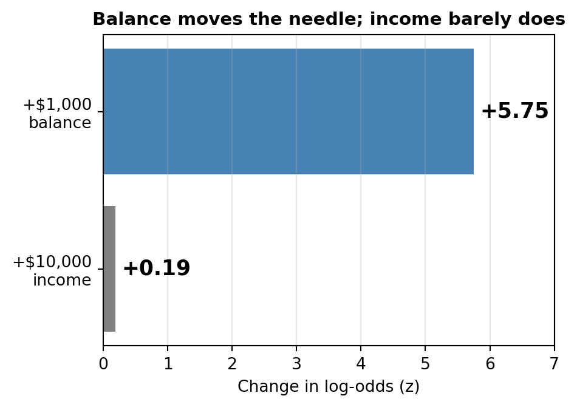

## Moving Along the S-Curve

What does **+5.75 log-odds** do to a real customer? Take one with a **$40,000 income**:

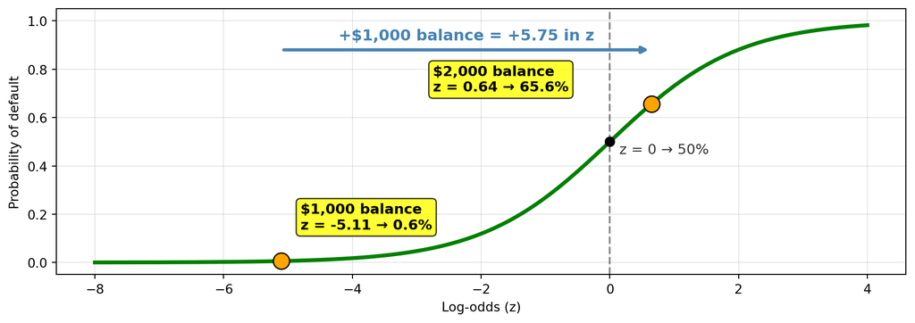

The coefficient tells us **how far we slide along z**. The S-curve turns that position into a probability: **0.6% → 66%**.

**Honestly? This is hard to interpret.**

Even experienced analysts don’t think in log-odds. In practice, we read the coefficients for **direction** (sign) and **rough magnitude** (which features matter most), then **convert to probabilities** for real customers to explain the results.

## From Coefficients to Predictions

So let’s do that. Let scikit-learn convert three customers, each with a **$40,000 income**, into probabilities:

```python
customers = pd.DataFrame({
    'balance': [1000, 1500, 2000],
    'income':  [40000, 40000, 40000]
})

customers.assign(prob_default=model.predict_proba(customers)[:, 1].round(3))
```

|  | balance | income | prob_default |
| --- | --- | --- | --- |
| 0 | 1000 | 40000 | 0.006 |
| 1 | 1500 | 40000 | 0.097 |
| 2 | 2000 | 40000 | 0.656 |

- $1,000 and $2,000 match our hand calculation: **0.6%** and **66%**
- $1,000 → $1,500: probability rises by ~9 points
- $1,500 → $2,000: probability rises by ~56 points
- **Same $500 step, very different jumps.** That’s the S-curve at work.

**Note**

`predict_proba()` returns two columns: P(class 0) and P(class 1). `[:, 1]` grabs the probability of **default**.

## How Good Is Our Model?

```python
from sklearn.metrics import accuracy_score

# Predict a class (0 or 1) for each test customer using the 50% threshold
y_pred = model.predict(X_test)

accuracy = accuracy_score(y_test, y_pred)
print(f"Model Accuracy: {accuracy:.1%}")
```

```
Model Accuracy: 97.1%
```

**Critical Question**

**97% accuracy!** Is this a good model for the bank?

How would you know?

# Beyond Accuracy: Why 97% Can Be Terrible

## Meet the Lazy Model

Last week, we asked whether our model beat **guessing the average**. Let’s ask the same thing here.

The **lazy model** ignores the data and predicts **“No default”** for every customer.

**Your guess?**

What accuracy would the lazy model get on our test set?

```python
import numpy as np

lazy_pred = np.zeros(len(y_test))   # predict 0 ("No default") for everyone
print(f"Lazy model accuracy: {accuracy_score(y_test, lazy_pred):.1%}")
print(f"Our model accuracy:  {accuracy:.1%}")
```

```
Lazy model accuracy: 96.7%
Our model accuracy:  97.1%
```

**Our model beats doing nothing by less than half a percentage point.** When one class is rare, accuracy hides how badly the model handles the class we actually care about.

## The Confusion Matrix: Four Possible Outcomes

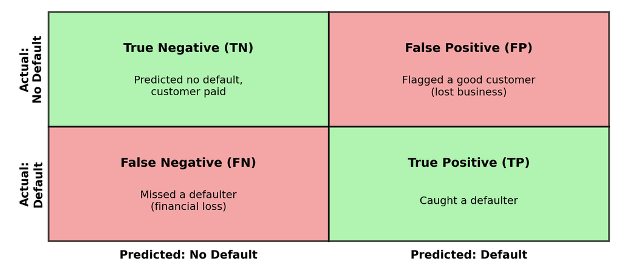

Accuracy lumps the two kinds of mistakes together. The confusion matrix **separates them**, because they rarely cost the business the same amount.

## Our Model’s Confusion Matrix

```python
from sklearn.metrics import confusion_matrix

cm = confusion_matrix(y_test, y_pred)
pd.DataFrame(
    cm,
    index=['Actual: No Default', 'Actual: Default'],
    columns=['Predicted: No Default', 'Predicted: Default']
)
```

|  | Predicted: No Default | Predicted: Default |
| --- | --- | --- |
| Actual: No Default | 2881 | 19 |
| Actual: Default | 67 | 33 |

**Read the bottom row**

Of the **100** customers who actually defaulted, the model caught only **33**. It **missed 67**, and every one of them is money the bank lent and won’t get back.

## Precision and Recall

Two questions that accuracy can’t answer:

🎯 Precision = TP / (TP + FP)

*When the model flags a customer, how often is it right?*

**Ours:** 33 / (33 + 19) = **0.63**

🔍 Recall = TP / (TP + FN)

*Of the customers who default, how many does it catch?*

**Ours:** 33 / (33 + 67) = **0.33**

```python
from sklearn.metrics import precision_score, recall_score

print(f"Precision: {precision_score(y_test, y_pred):.2f}")
print(f"Recall:    {recall_score(y_test, y_pred):.2f}")
```

```
Precision: 0.63
Recall:    0.33
```

**Note**

Like last week’s metric functions: **actual values first**, then the **predictions**.

## The Threshold Is a Dial

`predict()` flags a customer when the probability is **≥ 50%**. But nothing forces us to use 50%:

```python
probs = model.predict_proba(X_test)[:, 1]

results = []
for threshold in [0.3, 0.4, 0.5, 0.6, 0.7]:
    preds = (probs >= threshold).astype(int)
    tn, fp, fn, tp = confusion_matrix(y_test, preds).ravel()
    results.append({
        'threshold': threshold,
        'caught (TP)': tp,
        'missed (FN)': fn,
        'false alarms (FP)': fp,
        'accuracy': accuracy_score(y_test, preds),
        'precision': precision_score(y_test, preds),
        'recall': recall_score(y_test, preds)
    })

pd.DataFrame(results).round(3)
```

|  | threshold | caught (TP) | missed (FN) | false alarms (FP) | accuracy | precision | recall |
| --- | --- | --- | --- | --- | --- | --- | --- |
| 0 | 0.3 | 52 | 48 | 56 | 0.965 | 0.481 | 0.52 |
| 1 | 0.4 | 41 | 59 | 27 | 0.971 | 0.603 | 0.41 |
| 2 | 0.5 | 33 | 67 | 19 | 0.971 | 0.635 | 0.33 |
| 3 | 0.6 | 27 | 73 | 11 | 0.972 | 0.711 | 0.27 |
| 4 | 0.7 | 20 | 80 | 8 | 0.971 | 0.714 | 0.20 |

**Tip**

**Lower the threshold** → catch more defaulters (recall ↑) but flag more good customers (precision ↓). Notice that **accuracy barely moves** (96.5%–97.2%) while recall swings from 0.20 to 0.52. Accuracy can’t see this trade-off; **the business decides which mistakes it can live with.**

## Pick the Threshold

The bank estimates:

- **Missed defaulter (FN):** lose **$5,000** on average
- **False alarm (FP):** lose **$200** (a good customer gets a lower limit and takes their business elsewhere)

| Threshold | Missed (FN) | False alarms (FP) |
| --- | --- | --- |
| 50% | 67 | 19 |
| 30% | 48 | 56 |
| 20% | 40 | 91 |
| 10% | 23 | 183 |

**With your neighbor:** Which threshold costs the bank the least? Would your answer change if a false alarm cost $2,000?

## Pick the Threshold: The Answer

**Total cost** = Missed × $5,000 + False alarms × (cost per false alarm)

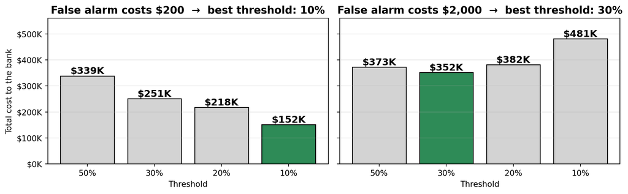

**Same model, different costs, different best threshold**

When a missed defaulter costs 25× more than a false alarm, it pays to flag aggressively (**10%**, far from the default 50%). Make false alarms more expensive and the best threshold moves back up (**30%**). The model doesn’t change; **the business costs decide where to set the dial.**

# Which Mistake Matters More?

## Which Mistake Costs More?

For each model, which error hurts more, and which metric should we focus on?

🏥 Cancer screening

Flags scans for follow-up tests

**FP:** healthy patient flagged → $1,500 in extra tests, anxiety

**FN:** cancer missed → $50,000+, potentially life-threatening

**→ Recall**

*“Did I catch them all?”*

Misses are far costlier than false alarms

💳 Fraud blocking

Auto-blocks suspicious card transactions

**FP:** legitimate purchase blocked → ~$500 in lost future business when frustrated customers switch cards

**FN:** fraud slips through → ~$200 loss (the bank reimburses it)

**→ Precision**

*“When I act, am I right?”*

A false alarm costs more than the fraud itself

📧 Discount offers

Sends 20%-off offers to likely buyers

**FP:** offer sent to a non-buyer → ~$4 wasted

**FN:** likely buyer skipped → ~$4 lost profit

**→ F1-score**

*“Balance the two”*

Both errors cost about the same

## Your Turn: Interview the Business

A regional gym chain asks you to build a model that predicts **which members will cancel in the next 60 days**.

Before you build anything, you need to decide **how to evaluate it**: accuracy, precision, recall, or F1?

**With your neighbor:** What questions would you ask the gym’s managers to help you decide? Aim for at least 3.

**Hint**

Think about what happens *after* the model makes a prediction, and what each kind of mistake would cost.

## Questions Worth Asking

| Ask the business… | Why it matters |
| --- | --- |
| **How many members cancel?** | If it’s rare (say 5%), accuracy is misleading. Compare to the lazy model. |
| **What will you do with flagged members?** | The action (a call, a free month) determines what a **false positive** costs |
| **What is a lost member worth?** | That’s what a **false negative** costs |
| **How many members can you act on?** | If staff can only call 50 a week, every flag needs to count → **precision** |
| **Which mistake would hurt more?** | Misses → **recall**, false alarms → **precision**, about equal → **F1** |

**Suppose the gym answers…**

About **5%** cancel. Flagged members get a **free month (~$40)**. A lost member is worth **~$600** a year. The front desk can reach everyone flagged.

**→ Prioritize recall.** A miss costs 15× more than a wasted free month, and there’s no limit on how many members they can contact. Then tune the threshold to the costs, just like we did for the bank.

# Looking Forward

## Key Takeaways

- **Classification vs. regression**: predicting a category needs a different model and different metrics
- **Logistic regression**: the S-curve turns a linear score into a valid probability
- **Interpretation**: a coefficient’s sign gives the direction; to talk about probability, plug in real examples
- **Compare to a baseline**: 97% accuracy means little when 97% of customers don’t default
- **Precision, recall, and the threshold**: the business’s error costs decide which mistakes to minimize

## More in Your Readings

📈 ROC curves & AUC

How well the model ranks customers by risk, across every threshold

⚖️ F1 & the harmonic mean

Why F1 punishes a model that is great at one metric and terrible at the other

💰 Business cost analysis

Putting a dollar value on each cell of the confusion matrix

🧩 Multiple predictors

Adding categorical features like `student` to a logistic regression

## Thursday’s Lab

**This Week’s Lab Preview**

In Thursday’s lab, you’ll get hands-on practice with:

- Building logistic regression models with real medical data to predict cancer
- Comparing against a baseline and reading the confusion matrix
- Evaluating models with precision, recall, F1-score, and ROC-AUC
- Turning error costs into a business recommendation

**Homework**

This week’s Lab will serve as your homework!

## Any Final Questions?

- About classification vs. regression?
- About interpreting logistic regression?
- About precision, recall, and thresholds?
- About Thursday’s lab?

**See you Thursday for hands-on classification analysis!**